# Ridge Regression

Caroline Svahn & Martina Sandberg

2015-10-16

# Ridgereg and the caret package

## 1.

Divide the `BostonHousing` data into a test and a training dataset using the `caret` package.

```r
library(RLab4)
library(mlbench)
library(caret)
data(BostonHousing)

trainIndex <- createDataPartition(BostonHousing$medv, p = .8, list = FALSE,times = 1)

Train <- BostonHousing[ trainIndex,]
Test  <- BostonHousing[-trainIndex,]
```

## 2.

Fit a linear regression model and a linear regression model with forward selection of covariates on the training dataset.

```r
 model1 <- train(medv ~ crim + indus + zn + chas +
                  nox + rm + age + dis + rad + tax + ptratio
                + b + lstat , data=Train , method = 'lm')
```

```r
model2 <- train(medv ~ crim + indus + zn + chas +
                  nox + rm + age + dis + rad + tax + ptratio
                + b + lstat , data=Train , method = 'leapForward')
summary(model2)
```

[output not shown]

```r
model2 <- train(medv ~ rm + dis + ptratio + lstat , data=Train , method = 'lm')
```

## 3.

Evaluate the performance of these two models on the training dataset.

```r
summary(model1)
```

```
##
## Call:
## lm(formula = .outcome ~ ., data = dat)
##
## Residuals:
##      Min       1Q   Median       3Q      Max
## -15.8265  -2.7495  -0.6255   1.6042  25.8829
##
## Coefficients:
##               Estimate Std. Error t value Pr(>|t|)
## (Intercept)  3.516e+01  5.793e+00   6.069 3.04e-09 ***
## crim        -1.058e-01  3.829e-02  -2.763 0.005988 **
## indus        2.750e-02  6.690e-02   0.411 0.681251
## zn           5.585e-02  1.567e-02   3.564 0.000410 ***
## chas1        2.893e+00  9.335e-01   3.099 0.002079 **
## nox         -1.735e+01  4.204e+00  -4.126 4.50e-05 ***
## rm           3.735e+00  4.813e-01   7.760 7.43e-14 ***
## age         -5.195e-04  1.518e-02  -0.034 0.972724
## dis         -1.506e+00  2.251e-01  -6.689 7.74e-11 ***
## rad          3.256e-01  7.451e-02   4.369 1.60e-05 ***
## tax         -1.306e-02  4.122e-03  -3.168 0.001655 **
## ptratio     -9.068e-01  1.455e-01  -6.232 1.18e-09 ***
## b            1.152e-02  3.110e-03   3.705 0.000242 ***
## lstat       -5.229e-01  5.686e-02  -9.196  < 2e-16 ***
## ---
## Signif. codes:  0 '***' 0.001 '**' 0.01 '*' 0.05 '.' 0.1 ' ' 1
##
## Residual standard error: 4.845 on 393 degrees of freedom
## Multiple R-squared:  0.7336, Adjusted R-squared:  0.7248
## F-statistic: 83.24 on 13 and 393 DF,  p-value: < 2.2e-16
```

```r
summary(model2)
```

```
##
## Call:
## lm(formula = .outcome ~ ., data = dat)
##
## Residuals:
##      Min       1Q   Median       3Q      Max
## -15.4594  -3.0202  -0.6861   1.8780  27.0718
##
## Coefficients:
##             Estimate Std. Error t value Pr(>|t|)
## (Intercept) 24.00747    4.62921   5.186 3.41e-07 ***
## rm           4.22728    0.48897   8.645  < 2e-16 ***
## dis         -0.54307    0.14498  -3.746 0.000206 ***
## ptratio     -0.94924    0.12907  -7.355 1.08e-12 ***
## lstat       -0.67192    0.05371 -12.509  < 2e-16 ***
## ---
## Signif. codes:  0 '***' 0.001 '**' 0.01 '*' 0.05 '.' 0.1 ' ' 1
##
## Residual standard error: 5.298 on 402 degrees of freedom
## Multiple R-squared:  0.6741, Adjusted R-squared:  0.6709
## F-statistic: 207.9 on 4 and 402 DF,  p-value: < 2.2e-16
```

In model 1 there is some non-significant parameters but in model 2 all parameters are significant. The R-squared are slightly better in model 1 and the residual standard error is also better in model 1. The p-value of the F-statistics are the same in both models. Because of the small differences between the models we would choose model 2 because it is smaller than model 1.

## 4.

Fit a ridge regression model using your `ridgereg()` function to the training dataset.

```r
RidgeModel <- list(type=c("Regression"), library="RLab4",loop=NULL)
par <- data.frame(parameter="lambda", class="numeric",label="Lambda")
RidgeModel$parameters <- par

grid <- function(x, y, len = NULL, search = "grid"){
  if(search == "grid") {
    out <- expand.grid(lambda = c(0, 10 ^ seq(-1, -4, length = len - 1)))
  } else {
    out <- data.frame(lambda = 10^runif(len, min = -5, 1))
  }
  out
}
RidgeModel$grid <- grid

list_fit <- function(x, y, lambda, param, lev, last, classProbs, ...){
  data <- as.data.frame(x)
  data$response <- y

  formula <- "response ~ "
  cov <- capture.output(cat(colnames(data), sep="+"))
  formula <- paste(formula, cov)
  formula <- as.formula(formula)

  RLab4::ridgereg(formula=formula, data=data, lambda=param$lambda)
}
RidgeModel$fit <- list_fit

pred <- function(modelFit, newdata, preProc=NULL, submodels=NULL){
  # RLab4::modelFit$predict(newdata)
  # predict(modelFit, newdata)
}
RidgeModel$predict <- pred

prob<- list(NULL)
RidgeModel$prob <- prob

RidgeModel$label <- "Ridgeregression"
```

```r
model3 <- train(medv ~ crim + indus + zn + chas +
                  nox + rm + age + dis + rad + tax + ptratio
                + b + lstat,data=Train,
                   method = "ridge")
model3
```

```
## Ridge Regression
##
## 407 samples
##  13 predictor
##
## No pre-processing
## Resampling: Bootstrapped (25 reps)
## Summary of sample sizes: 407, 407, 407, 407, 407, 407, ...
## Resampling results across tuning parameters:
##
##   lambda  RMSE      Rsquared   RMSE SD    Rsquared SD
##   0e+00   5.063577  0.7103595  0.4463520  0.04102427
##   1e-04   5.063438  0.7103754  0.4465025  0.04103962
##   1e-01   5.053551  0.7123908  0.5220549  0.04962647
##
## RMSE was used to select the optimal model using  the smallest value.
## The final value used for the model was lambda = 0.1.
```

Find the best hyperparameter value for lambda using 10-fold cross-validation.

```r
fitControl <- trainControl(method = "repeatedcv",number = 10,repeats = 10)
model4 <- train(medv ~ crim + indus + zn + chas +
                  nox + rm + age + dis + rad + tax + ptratio
                + b + lstat,data=Train,
                method = "ridge",
                trControl = fitControl)
model4
```

```
## Ridge Regression
##
## 407 samples
##  13 predictor
##
## No pre-processing
## Resampling: Cross-Validated (10 fold, repeated 10 times)
## Summary of sample sizes: 366, 367, 367, 364, 367, 366, ...
## Resampling results across tuning parameters:
##
##   lambda  RMSE      Rsquared   RMSE SD   Rsquared SD
##   0e+00   4.917906  0.7232296  1.086840  0.09798438
##   1e-04   4.917833  0.7232368  1.087029  0.09800526
##   1e-01   4.944467  0.7213063  1.196793  0.11061086
##
## RMSE was used to select the optimal model using  the smallest value.
## The final value used for the model was lambda = 1e-04.
```

## 5.

Evaluate the performance on the training dataset. (Fit a linear model with the best lambda=0.0001.)

```r
model5 <- ridgereg(medv ~ crim + indus + zn + chas +
           nox + rm + age + dis + rad + tax + ptratio
         + b + lstat , data=Train , 0.0001)
```

```r
model5$summary()
```

```
## $Coefficients
##                Estimate Std.Error     t value       p value
## (Intercept) 22.57616153 0.2401415 94.01192421 1.731355e-271
## crim        -0.89435704 0.3236349 -2.76347527  5.987893e-03
## indus        0.19069704 0.4639192  0.41105655  6.812551e-01
## zn           1.29349790 0.3628903  3.56443245  4.095146e-04
## chas1        0.77964753 0.2515542  3.09932287  2.079228e-03
## nox         -2.03890432 0.4941031 -4.12647575  4.499499e-05
## rm           2.60524157 0.3357429  7.75963202  7.426872e-14
## age         -0.01436154 0.4197320 -0.03421598  9.727223e-01
## dis         -3.18554517 0.4762281 -6.68911669  7.741885e-11
## rad          2.80452430 0.6418723  4.36928681  1.597166e-05
## tax         -2.17436164 0.6863499 -3.16800739  1.654867e-03
## ptratio     -1.99946626 0.3208143 -6.23247174  1.184240e-09
## b            1.06019444 0.2861455  3.70508899  2.416008e-04
## lstat       -3.71485659 0.4039598 -9.19610559  2.203256e-18
##
## $degrees_of_freedom
## [1] 393
##
## $residual_standard_error
## [1] 4.844672
```

## 6.

Evaluate the performance of all three models on the test dataset and write some concluding comments.

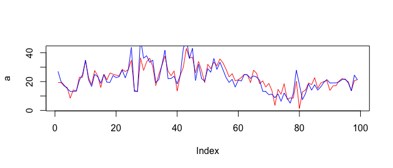

```r
a <- predict(model1, newdata = Test)
plot(a,type="l",col="red")
lines(Test$medv, col="blue")
```

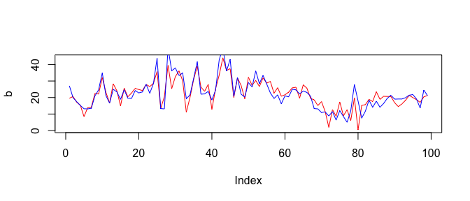

```r
b <- predict(model2, newdata = Test)
plot(b,type="l",col="red")
lines(Test$medv, col="blue")
```

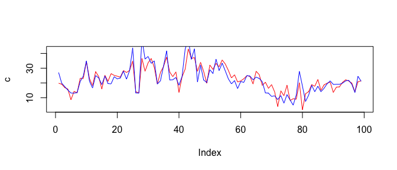

```r
c <- model5$predict(data=Test)
plot(c,type="l",col="red")
lines(Test$medv, col="blue")
```

```r
rmse <- function(error){
  sqrt(mean(error^2))
}
error1 <- a-Test$medv
rmse(error1)
```

```
## [1] 4.366779
```

```r
error2 <- b-Test$medv
rmse(error2)
```

```
## [1] 4.438186
```

```r
error3 <- c-Test$medv
rmse(error3)
```

```
## [1] 4.405432
```

we can see that the models perform quite equal. We would prefer model 2 because it is the smallest model which is easier to work with.